# Snow Data Assignment: Web Scraping, Functions, and Iteration

Alex Siggers

09 February, 2022

1. Extract the meteorological data URLs. Here we want you to use the `rvest` package to get the URLs for the `SASP forcing` and `SBSP_forcing` meteorological datasets.
2. Download the meteorological data. Use the `download_file` and `str_split_fixed` commands to download the data and save it in your data folder. You can use a for loop or a map function.
3. Write a custom function to read in the data and append a site column to the data.
4. Use the `map` function to read in both meteorological files. Display a summary of your tibble.
5. Make a line plot of mean temp by year by site (using the `air temp [K]` variable). Is there anything suspicious in the plot? Adjust your filtering if needed.

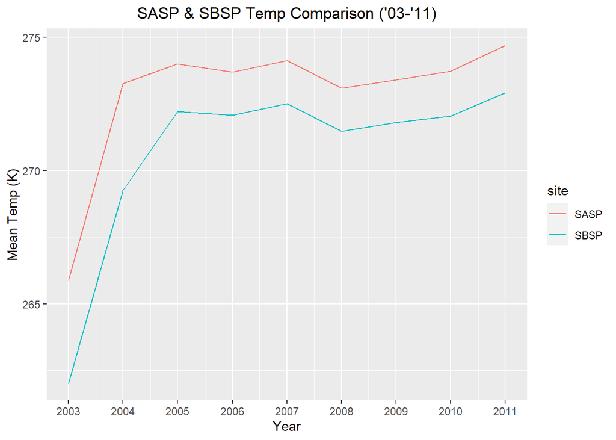

The temperature increases dramatically from the starting year (2003) and begins to level off & fluctuate closer to 2005. This is most likely due to the 2003 data being partial and only including winter temperatures. By filtering out 2003 and 2004, we can expect a more concise y-axis and remove outliers.

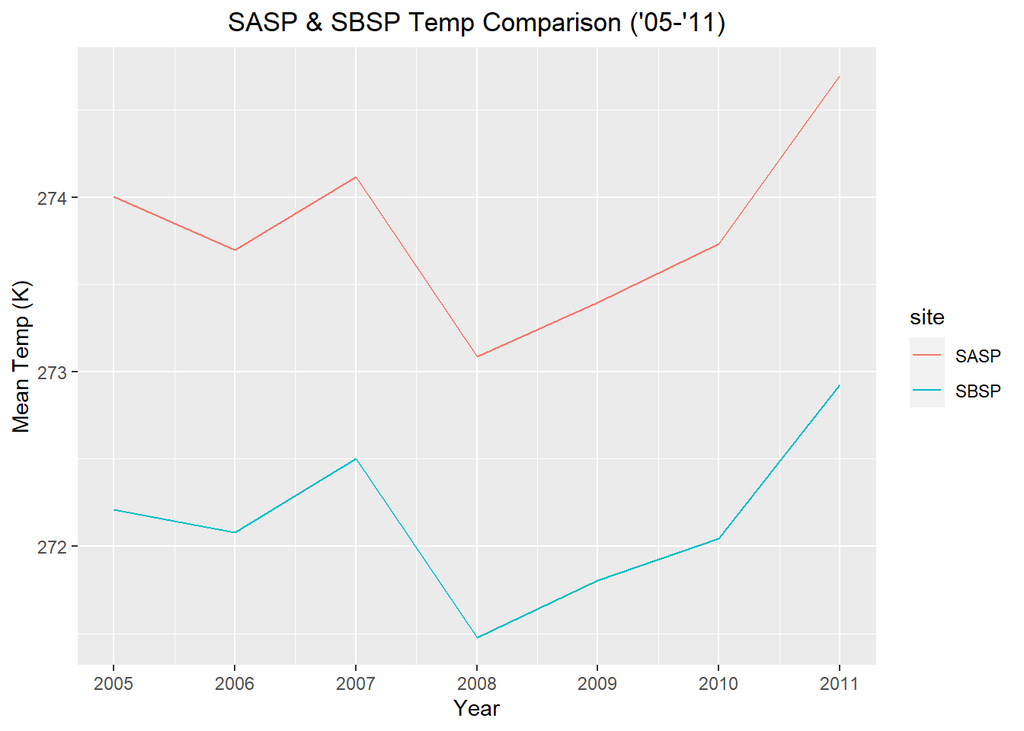

The updated graph gives a far less skewed insight into the temperature range of a seven-year span. Temperatures fluctuate between a ~3 K threshold. No more visible anomalies.

6. Write a function that makes line plots of monthly average temperature at each site for a given year. Use a for loop to make these plots for 2005 to 2010. Are monthly average temperatures at the Senator Beck Study Plot ever warmer than the Snow Angel Study Plot? Hint: https://ggplot2.tidyverse.org/reference/print.ggplot.html

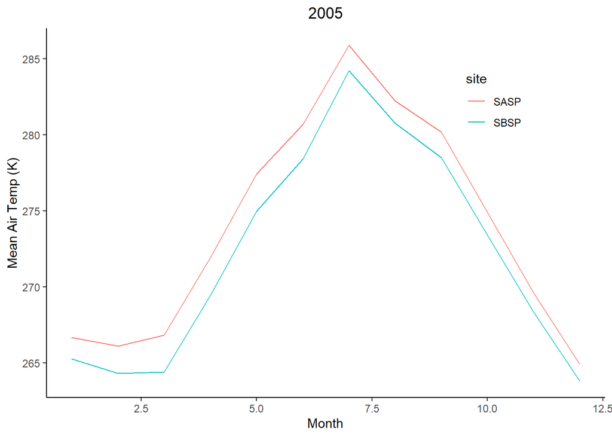

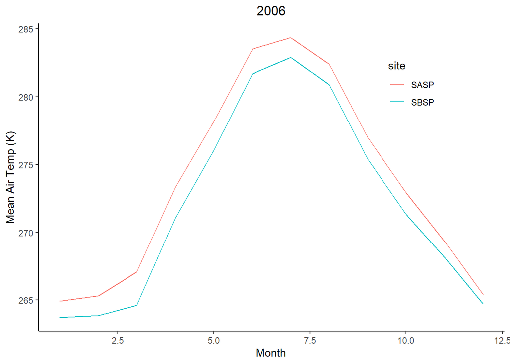

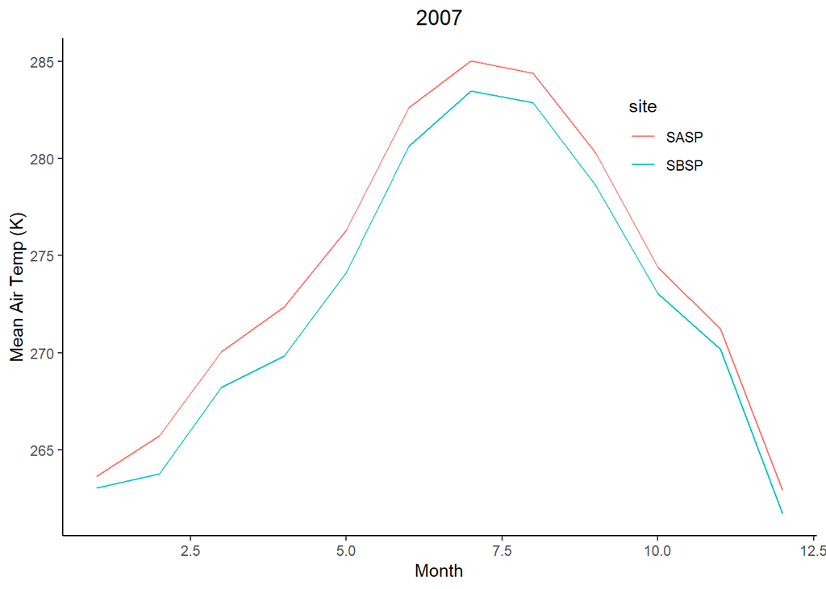

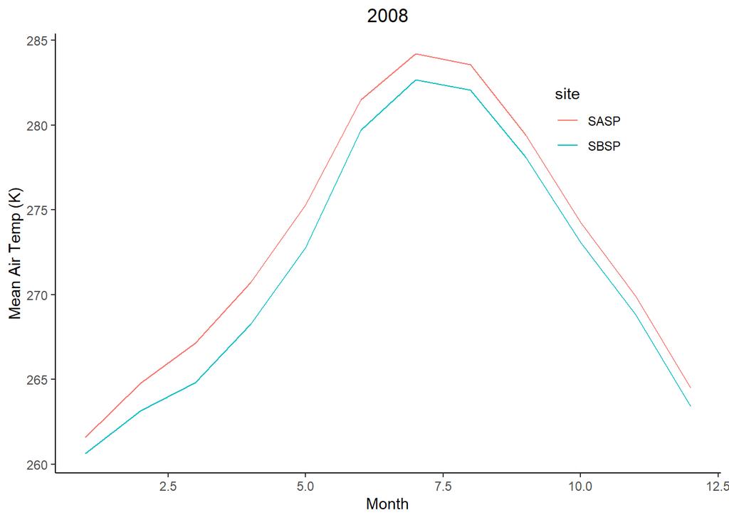

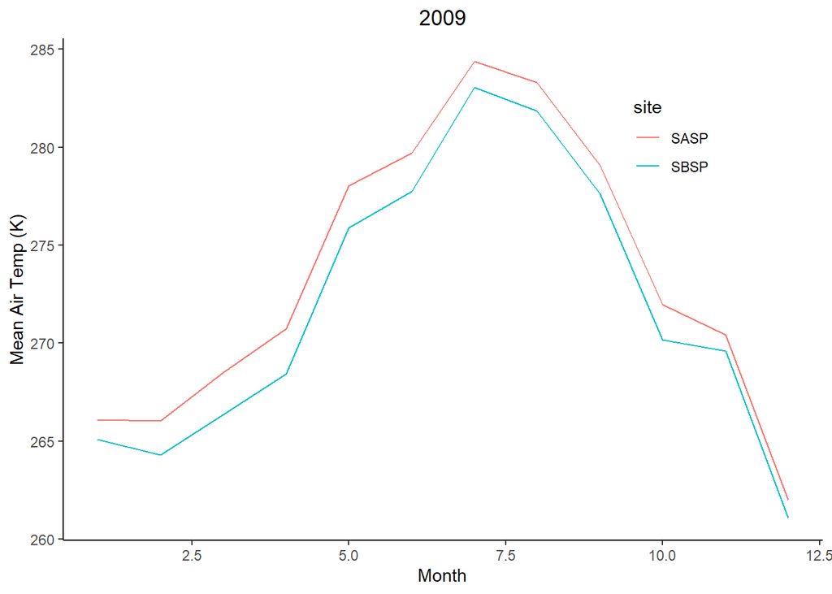

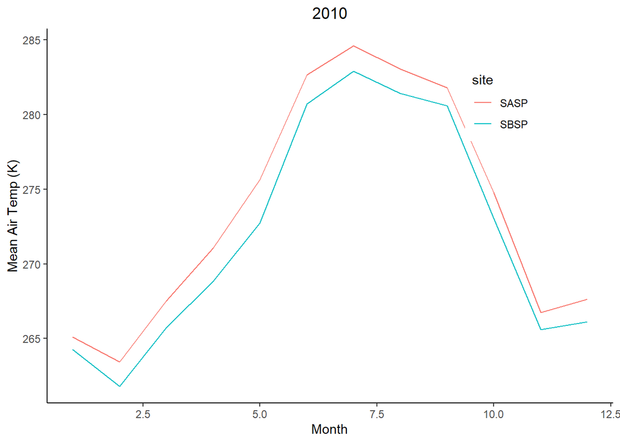

Bonus: Make a plot of average daily precipitation by day of year (averaged across all available years). Color each site.

Bonus #2: Use a function and for loop to create yearly plots of precipitation by day of year. Color each site.